# Chapter 7 - LME analysis of Mode and Nuclear Contours: lh_slope

Antoin Rodgers

5.6.2022

### LME model analysis using initial model.

Initial equation: lh_slope ~ mode + fin_phon + gender + (1 + mode | speaker) + (1 | prompt)

Prompt is used as an intercepts only random effect since the model does not converge when intercept and slope effect are both included.

NB: Gender caused singularity issues for another f0 parameter test (l_f0). However, it is not excluded here, since slope and f0 tonal targets are not directly comparable.

```
## Linear mixed model fit by REML. t-tests use Satterthwaite's method [
## lmerModLmerTest]
## Formula: formula(cur_equation)
##    Data: m_corpus
## Control:
## lmerControl(optimizer = "optimx", calc.derivs = FALSE, optCtrl = list(method = "nlminb",
##     starttests = FALSE, kkt = FALSE))
##
## REML criterion at convergence: 4561.9
##
## Scaled residuals:
##     Min      1Q  Median      3Q     Max
## -3.3287 -0.6363 -0.0673  0.5785  3.7571
##
## Random effects:
##  Groups   Name        Variance Std.Dev. Corr
##  speaker  (Intercept) 101.68   10.084
##           modeMWH      45.29    6.730   -0.61
##           modeMYN      20.97    4.579   -0.20 -0.21
##           modeMDQ      55.88    7.475   -0.48  0.24  0.60
##  prompt   (Intercept)  58.00    7.616
##  Residual              64.73    8.045
## Number of obs: 639, groups:  speaker, 11; prompt, 3
##
## Fixed effects:
##             Estimate Std. Error      df t value Pr(>|t|)
## (Intercept)   31.235      5.760   5.359   5.423  0.00233 **
## modeMWH        2.226      2.218  10.088   1.003  0.33917
## modeMYN        1.413      1.645   9.670   0.859  0.41117
## modeMDQ       10.725      2.435   8.991   4.405  0.00171 **
## fin_phonL%    -2.542      1.234 597.919  -2.060  0.03980 *
## genderM        5.438      4.498   9.033   1.209  0.25738
## ---
## Signif. codes:  0 '***' 0.001 '**' 0.01 '*' 0.05 '.' 0.1 ' ' 1
##
## Correlation of Fixed Effects:
##            (Intr) modMWH modMYN modMDQ fn_pL%
## modeMWH    -0.324
## modeMYN    -0.131 -0.054
## modeMDQ    -0.262  0.281  0.570
## fin_phonL% -0.023  0.016 -0.013 -0.026
## genderM    -0.355 -0.002  0.001  0.004 -0.015
```

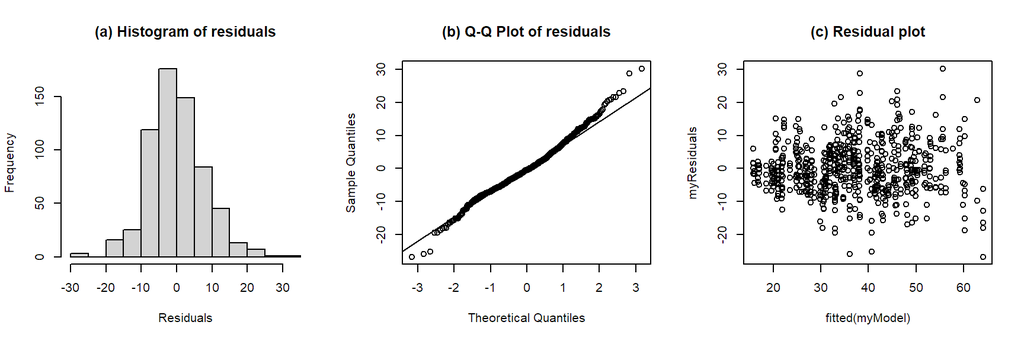

```
## Type III Analysis of Variance Table with Satterthwaite's method
##           Sum Sq Mean Sq NumDF  DenDF F value   Pr(>F)
## mode     1560.14  520.05     3   9.85  8.0344 0.005286 **
## fin_phon  274.76  274.76     1 597.92  4.2448 0.039804 *
## gender     94.60   94.60     1   9.03  1.4615 0.257377
## ---
## Signif. codes:  0 '***' 0.001 '**' 0.01 '*' 0.05 '.' 0.1 ' ' 1
```

```
## Check_singularity(temp_mdl, tolerance = 1e-05 --> FALSE
```

```
## Backward reduced random-effect table:
##
##                              Eliminated npar  logLik    AIC     LRT Df
## <none>                                    18 -2280.9 4597.9
## mode in (1 + mode | speaker)          0    9 -2325.3 4668.6  88.764  9
## (1 | prompt)                          0   17 -2420.2 4874.4 278.535  1
##                              Pr(>Chisq)
## <none>
## mode in (1 + mode | speaker)  2.882e-15 ***
## (1 | prompt)                  < 2.2e-16 ***
## ---
## Signif. codes:  0 '***' 0.001 '**' 0.01 '*' 0.05 '.' 0.1 ' ' 1
##
## Backward reduced fixed-effect table:
## Degrees of freedom method: Satterthwaite
##
##          Eliminated  Sum Sq Mean Sq NumDF  DenDF F value   Pr(>F)
## gender            1   94.60   94.60     1   9.03  1.4615 0.257377
## mode              0 1563.65  521.22     3   9.85  8.0521 0.005247 **
## fin_phon          0  276.72  276.72     1 597.48  4.2750 0.039108 *
## ---
## Signif. codes:  0 '***' 0.001 '**' 0.01 '*' 0.05 '.' 0.1 ' ' 1
##
## Model found:
## lh_slope ~ mode + fin_phon + (1 + mode | speaker) + (1 | prompt)
```

- Model found from step regression:
  - `lh_slope ~ mode + fin_phon + (1 + mode | speaker) + (1 | prompt)`
- Gender is non-significant.
- Unlike the l_f0 and h_f0 models, prompt is significant here. This is because slope is a composite parameter f0 / time parameter.
- Distribution of residuals is slightly leptokurtic.

```
## Linear mixed model fit by REML. t-tests use Satterthwaite's method [
## lmerModLmerTest]
## Formula: formula(cur_equation)
##    Data: m_corpus
## Control:
## lmerControl(optimizer = "optimx", calc.derivs = FALSE, optCtrl = list(method = "nlminb",
##     starttests = FALSE, kkt = FALSE))
##
## REML criterion at convergence: 4567.6
##
## Scaled residuals:
##     Min      1Q  Median      3Q     Max
## -3.3196 -0.6342 -0.0614  0.5650  3.7483
##
## Random effects:
##  Groups   Name        Variance Std.Dev. Corr
##  speaker  (Intercept) 96.85    9.841
##           modeMWH     45.31    6.731    -0.48
##           modeMYN     20.92    4.574    -0.36 -0.21
##           modeMDQ     55.70    7.463    -0.56  0.24  0.60
##  prompt   (Intercept) 57.99    7.615
##  Residual             64.73    8.046
## Number of obs: 639, groups:  speaker, 11; prompt, 3
##
## Fixed effects:
##             Estimate Std. Error      df t value Pr(>|t|)
## (Intercept)   33.707      5.344   4.134   6.307  0.00289 **
## modeMWH        2.228      2.219  10.088   1.004  0.33872
## modeMYN        1.414      1.643   9.670   0.860  0.41038
## modeMDQ       10.728      2.432   8.985   4.412  0.00170 **
## fin_phonL%    -2.550      1.233 597.482  -2.068  0.03911 *
## ---
## Signif. codes:  0 '***' 0.001 '**' 0.01 '*' 0.05 '.' 0.1 ' ' 1
##
## Correlation of Fixed Effects:
##            (Intr) modMWH modMYN modMDQ
## modeMWH    -0.278
## modeMYN    -0.215 -0.053
## modeMDQ    -0.316  0.281  0.569
## fin_phonL% -0.030  0.016 -0.013 -0.026
```

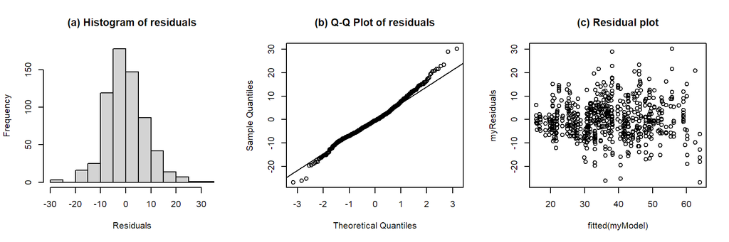

```
## Type III Analysis of Variance Table with Satterthwaite's method
##           Sum Sq Mean Sq NumDF  DenDF F value   Pr(>F)
## mode     1563.65  521.22     3   9.85  8.0521 0.005247 **
## fin_phon  276.72  276.72     1 597.48  4.2750 0.039108 *
## ---
## Signif. codes:  0 '***' 0.001 '**' 0.01 '*' 0.05 '.' 0.1 ' ' 1
```

```
##
##
## Check_singularity(temp_mdl, tolerance = 1e-05 --> FALSE
```

- Distribution of still residuals is leptokurtic.

### LME model analysis using reduced model and removing outliers (|residual|>2.5)

Running new model again but trimming rows with |residual| > 2.5 (as per Baayen 2008: 279-282).

```
## Linear mixed model fit by REML. t-tests use Satterthwaite's method [
## lmerModLmerTest]
## Formula: formula(cur_equation)
##    Data: m_corpus.trimmed
## Control:
## lmerControl(optimizer = "optimx", calc.derivs = FALSE, optCtrl = list(method = "nlminb",
##     starttests = FALSE, kkt = FALSE))
##
## REML criterion at convergence: 4471.9
##
## Scaled residuals:
##     Min      1Q  Median      3Q     Max
## -2.8072 -0.6517 -0.0670  0.5856  3.2376
##
## Random effects:
##  Groups   Name        Variance Std.Dev. Corr
##  speaker  (Intercept) 91.08    9.544
##           modeMWH     34.50    5.873    -0.44
##           modeMYN     25.58    5.058    -0.33 -0.26
##           modeMDQ     60.24    7.761    -0.52  0.12  0.64
##  prompt   (Intercept) 57.84    7.605
##  Residual             58.49    7.648
## Number of obs: 634, groups:  speaker, 11; prompt, 3
##
## Fixed effects:
##             Estimate Std. Error      df t value Pr(>|t|)
## (Intercept)   33.462      5.286   4.001   6.330  0.00319 **
## modeMWH        2.242      1.966  10.020   1.140  0.28076
## modeMYN        1.596      1.746   9.713   0.914  0.38278
## modeMDQ       11.391      2.501   9.128   4.555  0.00133 **
## fin_phonL%    -2.158      1.179 603.122  -1.830  0.06768 .
## ---
## Signif. codes:  0 '***' 0.001 '**' 0.01 '*' 0.05 '.' 0.1 ' ' 1
##
## Correlation of Fixed Effects:
##            (Intr) modMWH modMYN modMDQ
## modeMWH    -0.250
## modeMYN    -0.196 -0.101
## modeMDQ    -0.292  0.177  0.605
## fin_phonL% -0.030  0.018 -0.011 -0.022
```

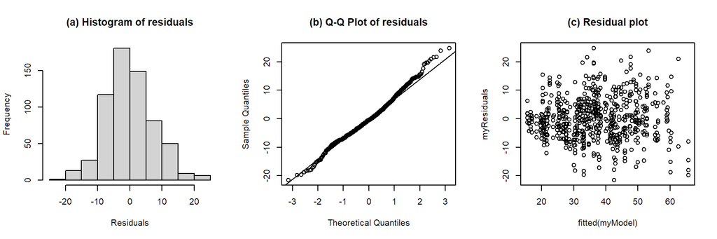

```
## Type III Analysis of Variance Table with Satterthwaite's method
##           Sum Sq Mean Sq NumDF  DenDF F value   Pr(>F)
## mode     1530.97  510.32     3   9.80  8.7253 0.004034 **
## fin_phon  195.95  195.95     1 603.12  3.3504 0.067684 .
## ---
## Signif. codes:  0 '***' 0.001 '**' 0.01 '*' 0.05 '.' 0.1 ' ' 1
```

```
##
##
## Check_singularity(temp_mdl.trimmed, tolerance = 1e-05 --> FALSE
```

Data trimmed from model

| speaker | gender | mode | prompt | phr_phon | lh_slope | lh_slope_z |
| --- | --- | --- | --- | --- | --- | --- |
| F5 | F | MDC | 2 | % (*) L*H % | 85.865 | 25.464 |
| F5 | F | MDQ | 2 | ^[% (*) L*H %] | 37.236 | 11.043 |
| F15 | F | MDQ | 1 | % L*H L*H % | 10.059 | 4.670 |
| M8 | M | MWH | 1 | % H* >!H* L*H % | 67.031 | 23.267 |
| M10 | M | MDQ | 1 | % L*H L*H L% | 15.496 | 6.041 |

- Distribution of residuals is more reasonable after removing outliers.

### Final model: lh_slope ~ mode + fin_phon + (1 + mode | speaker) + (1 | prompt)

#### Analysis of model

Intercept and slopes of fixed effects: lh_slope ~ mode + fin_phon + (1 + mode | speaker) + (1 | prompt)

| term | estimate | std.error | 2.5% CI | 97.5% CI | t.value | df | p.value | p.adj. (bf=7) |
| --- | --- | --- | --- | --- | --- | --- | --- | --- |
| (Intercept) | 33.707 | 5.344 | 23.233 | 44.181 | 6.307 | 4.13 | 0.0029 | 0.0202 |
| modeMWH | 2.228 | 2.219 | -2.120 | 6.577 | 1.004 | 10.09 | 0.3387 | 0.9999 |
| modeMYN | 1.414 | 1.643 | -1.807 | 4.635 | 0.860 | 9.67 | 0.4104 | 0.9999 |
| modeMDQ | 10.728 | 2.432 | 5.962 | 15.493 | 4.412 | 8.98 | 0.0017 | 0.0119 |
| fin_phonL% | -2.550 | 1.233 | -4.967 | -0.133 | -2.068 | 597.48 | 0.0391 | NA |

Conditional and marginal R<sup>2</sup> of model

| R2_conditional | R2_marginal | optional |
| --- | --- | --- |
| 0.71 | 0.08 | FALSE |

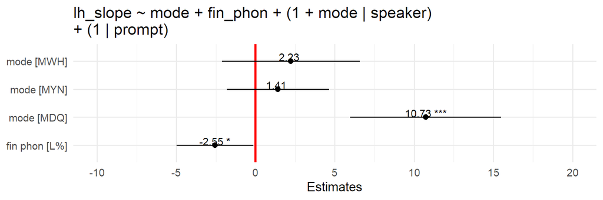

#### Summary of intercepts

b0 for lh_slope ~ mode + fin_phon + (1 + mode | speaker) + (1 | prompt)

| intercept | estimate | std.error | 2.5% CI | 97.5% CI | t.value | df | p.value | p.adj. (bf=7) | signif. (adj.) |
| --- | --- | --- | --- | --- | --- | --- | --- | --- | --- |
| modeMDC | 33.707 | 5.344 | 23.233 | 44.181 | 6.307 | 4.13 | 0.0029 | 0.0202 | p<0.05 |
| modeMWH | 35.935 | 5.185 | 25.773 | 46.097 | 6.931 | 3.72 | 0.003 | 0.0208 | p<0.05 |
| modeMYN | 35.121 | 5.243 | 24.845 | 45.397 | 6.699 | 3.87 | 0.0029 | 0.0204 | p<0.05 |
| modeMDQ | 44.435 | 5.124 | 34.392 | 54.477 | 8.672 | 3.56 | 0.0016 | 0.0113 | p<0.05 |

#### Summary of pairwise comparisons

b1 for lh_slope ~ mode + fin_phon + (1 + mode | speaker) + (1 | prompt)

| intercept | slope | estimate | std.error | 2.5% CI | 97.5% CI | t.value | df | p.value | p.adj. (bf=7) | signif. (adj.) |
| --- | --- | --- | --- | --- | --- | --- | --- | --- | --- | --- |
| modeMDC | modeMWH | 2.228 | 2.219 | -2.120 | 6.577 | 1.004 | 10.09 | 0.3387 | 0.9999 |  |
| modeMDC | modeMYN | 1.414 | 1.643 | -1.807 | 4.635 | 0.860 | 9.67 | 0.4104 | 0.9999 |  |
| modeMDC | modeMDQ | 10.728 | 2.432 | 5.962 | 15.493 | 4.412 | 8.98 | 0.0017 | 0.0119 | p<0.05 |
| modeMWH | modeMYN | -0.814 | 2.831 | -6.362 | 4.733 | -0.288 | 9.97 | 0.7794 | 0.9999 |  |
| modeMWH | modeMDQ | 8.499 | 2.794 | 3.023 | 13.976 | 3.042 | 9.45 | 0.0132 | 0.0926 |  |
| modeMYN | modeMDQ | 9.314 | 2.016 | 5.362 | 13.266 | 4.619 | 9.49 | 0.0011 | 0.0076 | p<0.01 |